# 04 - Visualizing spatial data, and more

September 7, 2017

## Getting started

## Follow up from last time…

- Everyone in sitting with their teams?
- Any questions on material from last time?
- Any questions on homework?
- A few of you still don't have photos on your GitHub profiles

## Reading recap

## `openintro` package

For the following we'll be using the `email` dataset from the `openintro` package:

```r
library(openintro)
```

## Shapes of distributions

How would you describe the shape of this distribution?

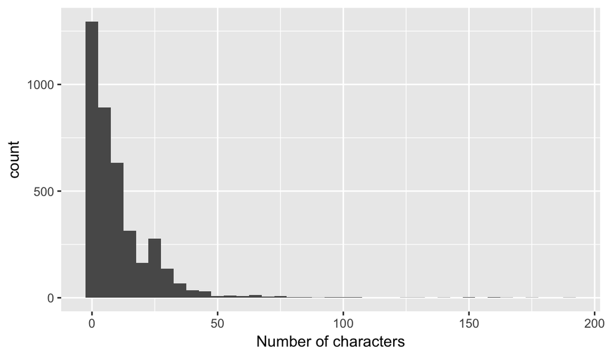

```r
ggplot(email, aes(x = num_char)) +
  geom_histogram(binwidth = 5) +
  labs(x = "Number of characters")
```

## Binwidth

Which of the following seems like a reasonable binwidth?

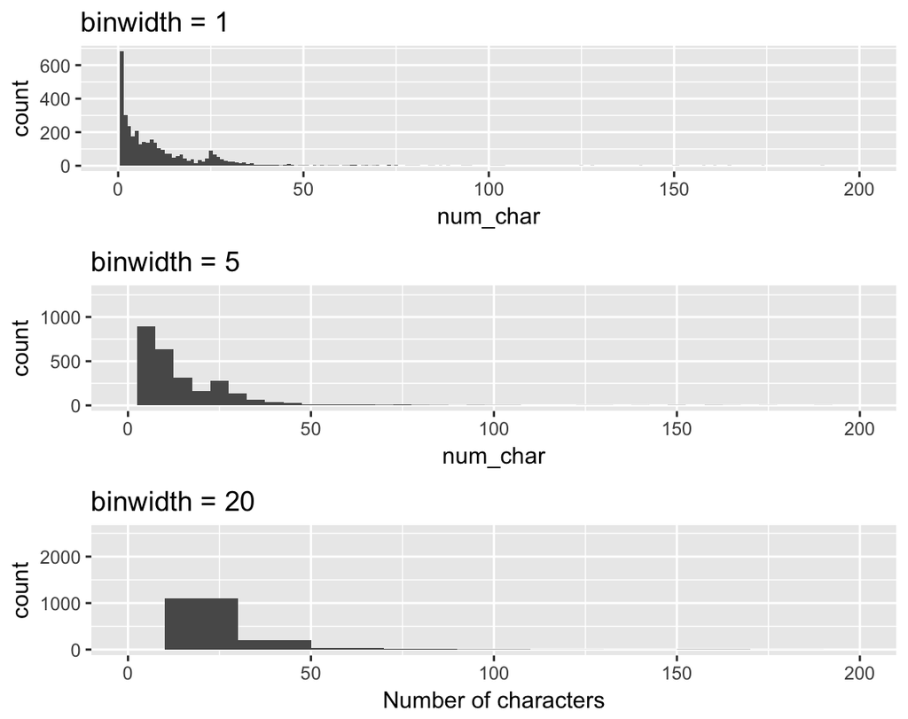

## Measures of center

**TEAM:** There are 3921 emails in this dataset. What is roughly the median number of line breaks in emails in this dataset? Is the average (mean) expected to be higher or lower than that value, and why?

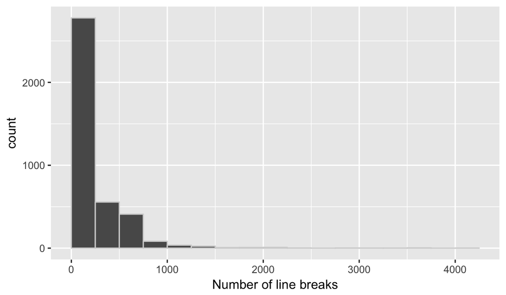

## Boxplots

How do the distributions of number of characters vary between emails that contain no numbers, small numbers, or big numbers?

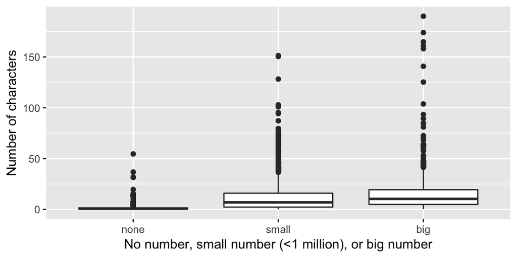

```r
ggplot(data = email, aes(x = number, y = num_char)) +
  geom_boxplot() +
  labs(x = "No number, small number (<1 million), or big number",
       y = "Number of characters")
```

## Segmented bar plots

Which of the following is a more useful representation for evaluating whether emails with subjects that start with "re:" are more likely to be categorized as spam or not?

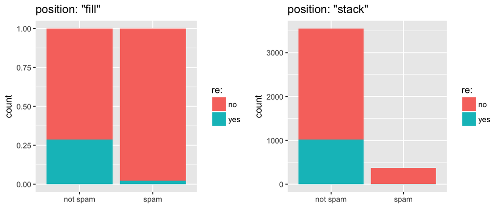